# ActivityMD

Iva

2025-11-10

# R Markdown

## Question 1

I am here showing any code that is needed to Load the data (i.e. read.csv()), and Process/transform the data (if necessary) into a format suitable for my analysis.

```r
# If the file isn't present, download and unzip it
if (!file.exists("activity.csv")) {
  if (!file.exists("activity.zip")) {
    download.file(
      "https://d396qusza40orc.cloudfront.net/repdata%2Fdata%2Factivity.zip",
      destfile = "activity.zip", mode = "wb"
    )
  }
  unzip("activity.zip")
}

activity <- read.csv("activity.csv", stringsAsFactors = FALSE)

# Transform to a format suitable: donvert date to Date, interval to integer
activity$date <- as.Date(activity$date)
activity$interval <- as.integer(activity$interval)

# Visualise
str(activity)
```

```
## 'data.frame':    17568 obs. of  3 variables:
##  $ steps   : int  NA NA NA NA NA NA NA NA NA NA ...
##  $ date    : Date, format: "2012-10-01" "2012-10-01" ...
##  $ interval: int  0 5 10 15 20 25 30 35 40 45 ...
```

```r
summary(activity)
```

```
##      steps             date               interval
##  Min.   :  0.00   Min.   :2012-10-01   Min.   :   0.0
##  1st Qu.:  0.00   1st Qu.:2012-10-16   1st Qu.: 588.8
##  Median :  0.00   Median :2012-10-31   Median :1177.5
##  Mean   : 37.38   Mean   :2012-10-31   Mean   :1177.5
##  3rd Qu.: 12.00   3rd Qu.:2012-11-15   3rd Qu.:1766.2
##  Max.   :806.00   Max.   :2012-11-30   Max.   :2355.0
##  NA's   :2304
```

## Question 2

What is mean total number of steps taken per day?

For this part of the assignment, you can ignore the missing values in the dataset. Make a histogram of the total number of steps taken each day Calculate and report the mean and median total number of steps taken per day

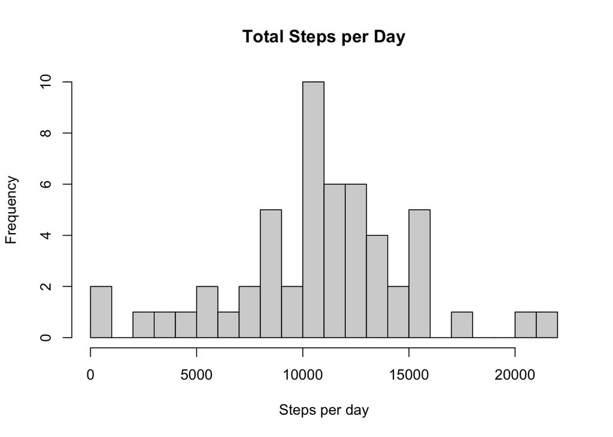

```r
# Ignore NA for this section (drop rows with NA in steps)
noNA <- subset(activity, !is.na(steps))

# Total steps per day
steps_per_day <- aggregate(steps ~ date, data = noNA, sum)

# Histogram of total steps per day
hist(steps_per_day$steps, breaks = 20,
     main = "Total Steps per Day",
     xlab = "Steps per day")
```

```r
mean_steps <- mean(steps_per_day$steps)
median_steps <- median(steps_per_day$steps)
mean_steps; median_steps
```

```
## [1] 10766.19
```

```
## [1] 10765
```

## Question 3

What is the average daily activity pattern?

Make a time series plot (i.e. type = “l”) of the 5-minute interval (x-axis) and the average number of steps taken, averaged across all days (y-axis) Which 5-minute interval, on average across all the days in the dataset, contains the maximum number of steps?

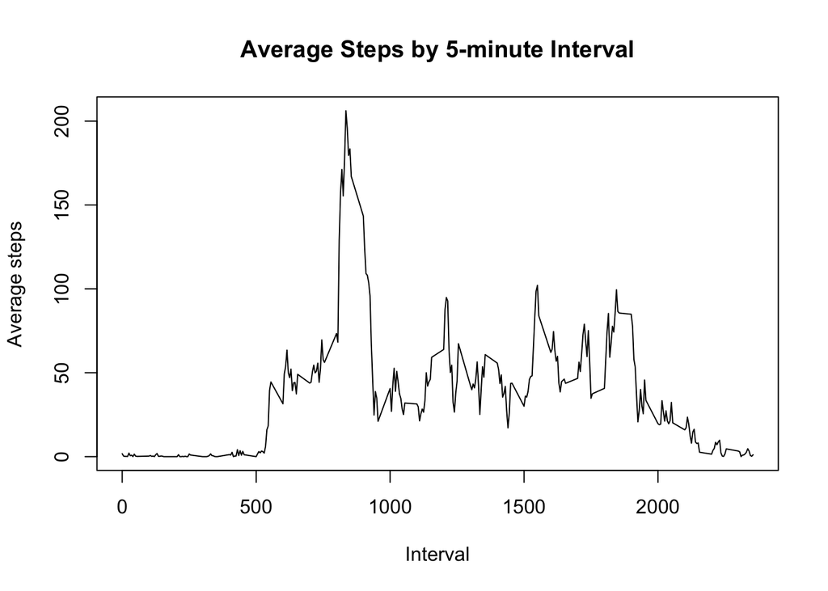

```r
# Average steps for each 5-minute interval across all days
interval_mean <- aggregate(steps ~ interval, data = noNA, mean)

# Time series plot
plot(interval_mean$interval, interval_mean$steps, type = "l",
     main = "Average Steps by 5-minute Interval",
     xlab = "Interval", ylab = "Average steps")
```

```r
# Interval with maximum average steps
max_int <- interval_mean$interval[which.max(interval_mean$steps)]
max_val <- max(interval_mean$steps)
max_int; max_val
```

```
## [1] 835
```

```
## [1] 206.1698
```

## Question 4

Imputing missing values

Note that there are a number of days/intervals where there are missing values (coded as NA). The presence of missing days may introduce bias into some calculations or summaries of the data.

Calculate and report the total number of missing values in the dataset (i.e. the total number of rows with NAs)

Devise a strategy for filling in all of the missing values in the dataset. The strategy does not need to be sophisticated. For example, you could use the mean/median for that day, or the mean for that 5-minute interval, etc.

Create a new dataset that is equal to the original dataset but with the missing data filled in.

Make a histogram of the total number of steps taken each day and Calculate and report the mean and median total number of steps taken per day. Do these values differ from the estimates from the first part of the assignment? What is the impact of imputing missing data on the estimates of the total daily number of steps?

```r
# Total number of missing values in steps
total_NA <- sum(is.na(activity$steps))
total_NA
```

```
## [1] 2304
```

```r
# Create a named vector of interval means
int_mean_vec <- setNames(interval_mean$steps, interval_mean$interval)

# Copy data and impute
activity_imputed <- activity
miss_idx <- which(is.na(activity_imputed$steps))
activity_imputed$steps[miss_idx] <- int_mean_vec[ as.character(activity_imputed$interval[miss_idx]) ]

# Sanity check: no NAs remain
sum(is.na(activity_imputed$steps))
```

```
## [1] 0
```

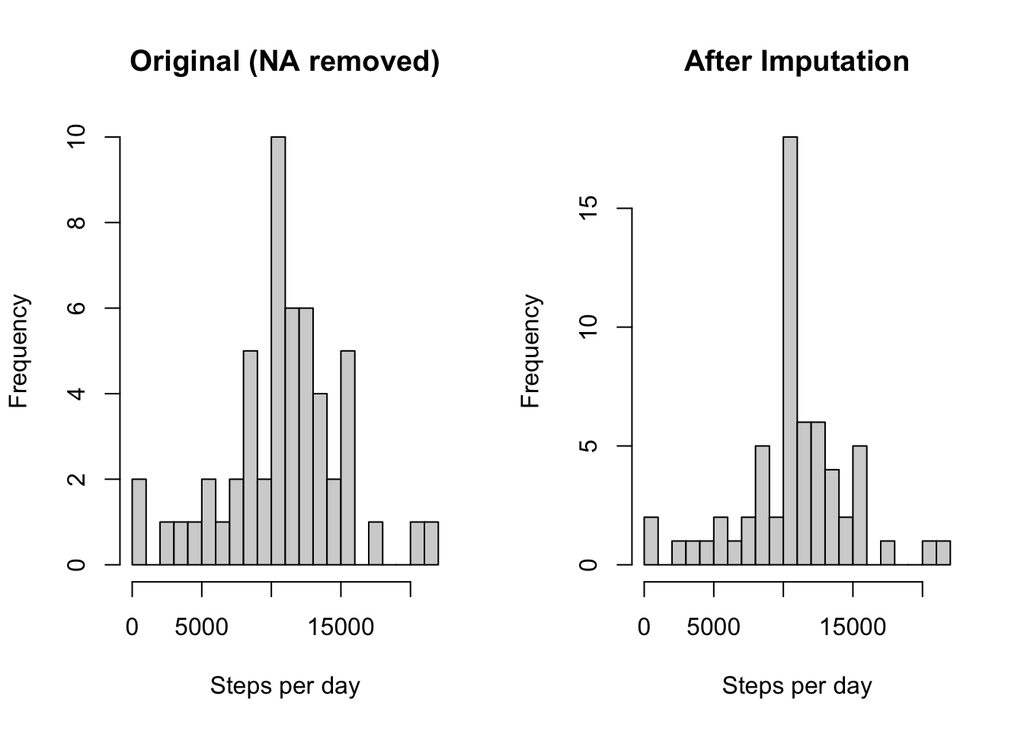

```r
# Total steps per day (imputed)
steps_per_day_imp <- aggregate(steps ~ date, data = activity_imputed, sum)

par(mfrow = c(1,2))
hist(steps_per_day$steps, breaks = 20, main = "Original (NA removed)",
     xlab = "Steps per day")
hist(steps_per_day_imp$steps, breaks = 20, main = "After Imputation",
     xlab = "Steps per day")
```

```r
par(mfrow = c(1,1))

mean_imp <- mean(steps_per_day_imp$steps)
median_imp <- median(steps_per_day_imp$steps)

data.frame(
  Metric = c("Mean (original)", "Median (original)", "Mean (imputed)", "Median (imputed)"),
  Value  = c(mean_steps, median_steps, mean_imp, median_imp)
)
```

```
##              Metric    Value
## 1   Mean (original) 10766.19
## 2 Median (original) 10765.00
## 3    Mean (imputed) 10766.19
## 4  Median (imputed) 10766.19
```

## Question 5

Are there differences in activity patterns between weekdays and weekends?

For this part the weekdays() function may be of some help here. Use the dataset with the filled-in missing values for this part.

Create a new factor variable in the dataset with two levels – “weekday” and “weekend” indicating whether a given date is a weekday or weekend day.

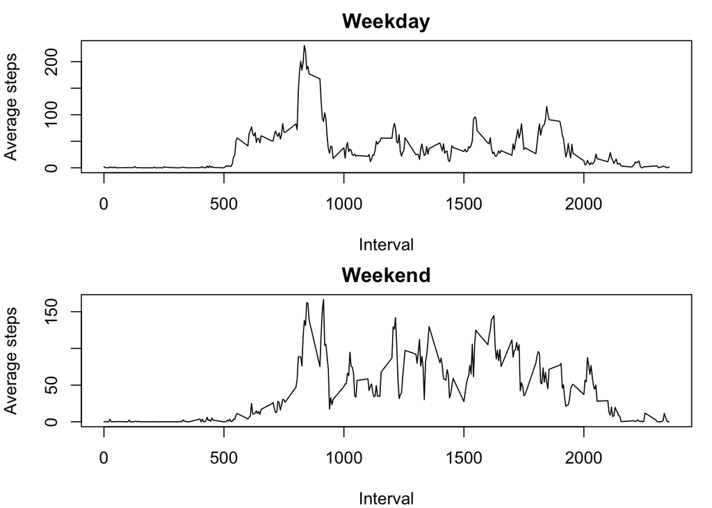

```r
# Use imputed dataset for this part
wd <- weekdays(activity_imputed$date)

activity_imputed$daytype <- ifelse(wd %in% c("Saturday","Sunday"), "weekend", "weekday")
activity_imputed$daytype <- factor(activity_imputed$daytype, levels = c("weekday","weekend"))

# Average steps by interval and daytype
interval_daytype <- aggregate(steps ~ interval + daytype, data = activity_imputed, mean)

# Panel plot (base)
par(mfrow = c(2,1), mar = c(4,4,2,1))
with(subset(interval_daytype, daytype == "weekday"),
     plot(interval, steps, type = "l", main = "Weekday", xlab = "Interval", ylab = "Average steps"))
with(subset(interval_daytype, daytype == "weekend"),
     plot(interval, steps, type = "l", main = "Weekend", xlab = "Interval", ylab = "Average steps"))
```

```r
par(mfrow = c(1,1))
```